# Deterministic Trend vs Random Trend

[Nao Mimoto](https://nmimoto.github.io/) - [Dept. of Statistics](http://www.uakron.edu/stat/) : [The University of Akron](http://www.uakron.edu)

[Class Web Page](https://nmimoto.github.io/477/)

## 1. Classical Decomposition

Additive Model can be written as
$$Y_t = T_t + X_t,$$
where $X_t$ is stationary time series. The trend $T_t$ may be determinisitc, or random.

Multiplicative Model is
$$Y_t = T_t \cdot X_t.$$

If you take **log()** of multiplicative model, it becomes additive model.

## 2. Deterministic Trend vs Random Trend

### Regression for Deterministic Trend

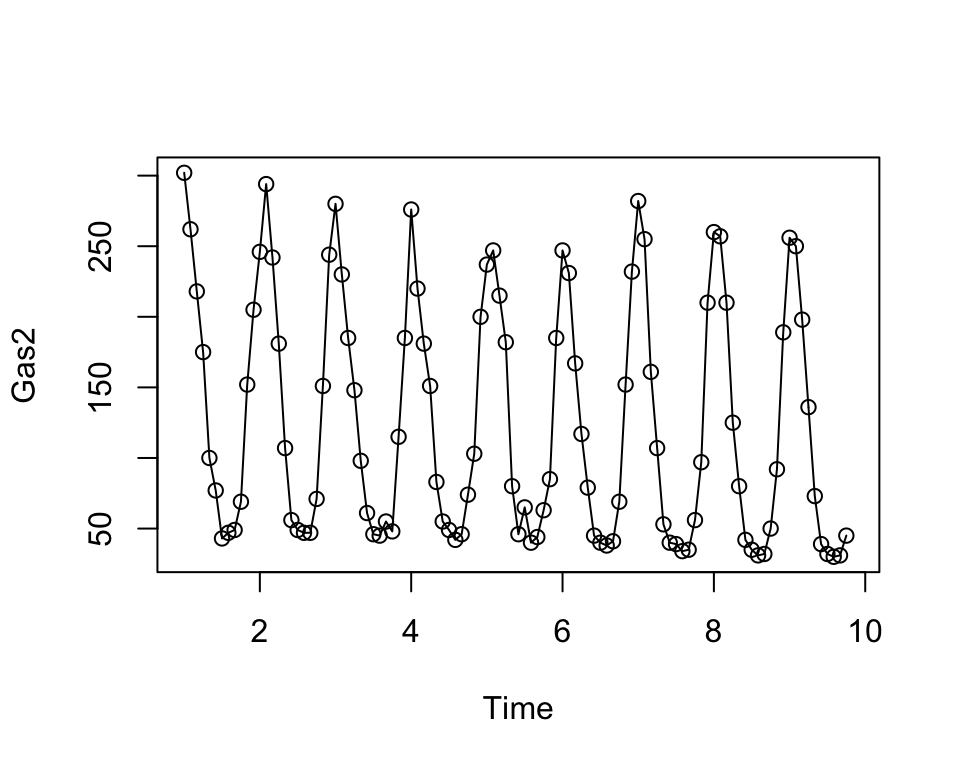

```r
  # Montly av. residential gas usage Iowa (cubic feet)*100 ’71 – ’79
  D <- read.csv("https://nmimoto.github.io/datasets/gas2.csv", header=T)
  Gas2 <- ts(D[,2], start=c(1, 1), freq=12)
  plot(Gas2, type='o')
```

```r
  Y = Gas2

  t = 1:length(Y)
  Fit01 <- lm(Y ~ t)
  summary(Fit01)
```

```
##
## Call:
## lm(formula = Y ~ t)
##
## Residuals:
##     Min      1Q  Median      3Q     Max
## -104.42  -73.56  -32.02   71.61  166.82
##
## Coefficients:
##             Estimate Std. Error t value Pr(>|t|)
## (Intercept) 150.8356    16.2771   9.267 2.92e-15 ***
## t            -0.4884     0.2641  -1.849   0.0673 .
## ---
## Signif. codes:  0 '***' 0.001 '**' 0.01 '*' 0.05 '.' 0.1 ' ' 1
##
## Residual standard error: 83.2 on 104 degrees of freedom
##   (1 observation deleted due to missingness)
## Multiple R-squared:  0.03183,    Adjusted R-squared:  0.02252
## F-statistic:  3.42 on 1 and 104 DF,  p-value: 0.06727
```

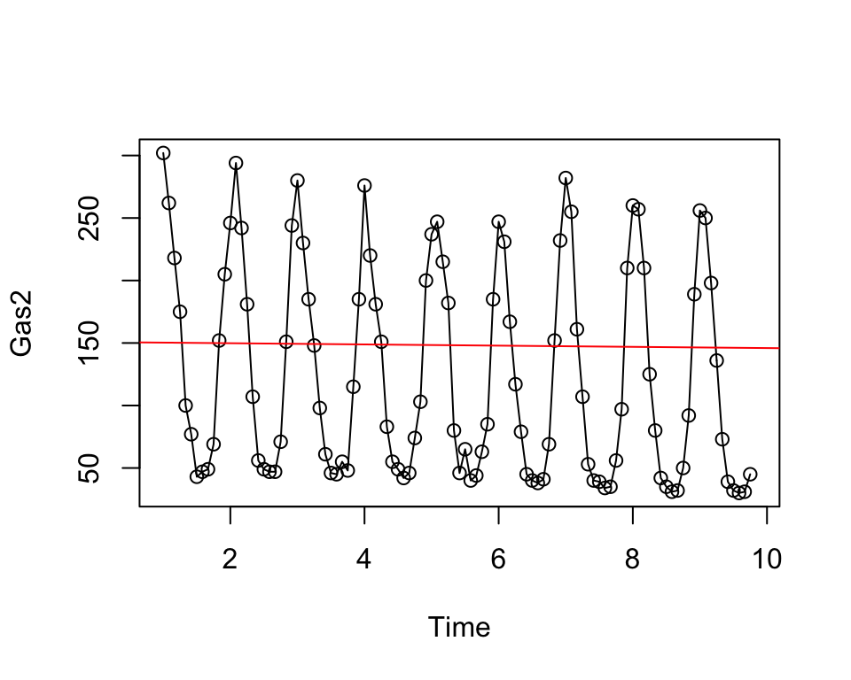

```r
  plot(Gas2, type='o')
  abline(Fit01, col="red")       # overlay fitted line
```

### Random Trend

We try to model the random trend with Random Walk.

## 3. Random Walk

Is a leading candidate to model random trend. Let $\epsilon_t \sim_{i.i.d.} N(\mu, \sigma)$. Then
$$X_t = \sum_{i=1}^t \epsilon_{i}$$
is called Random Walk.

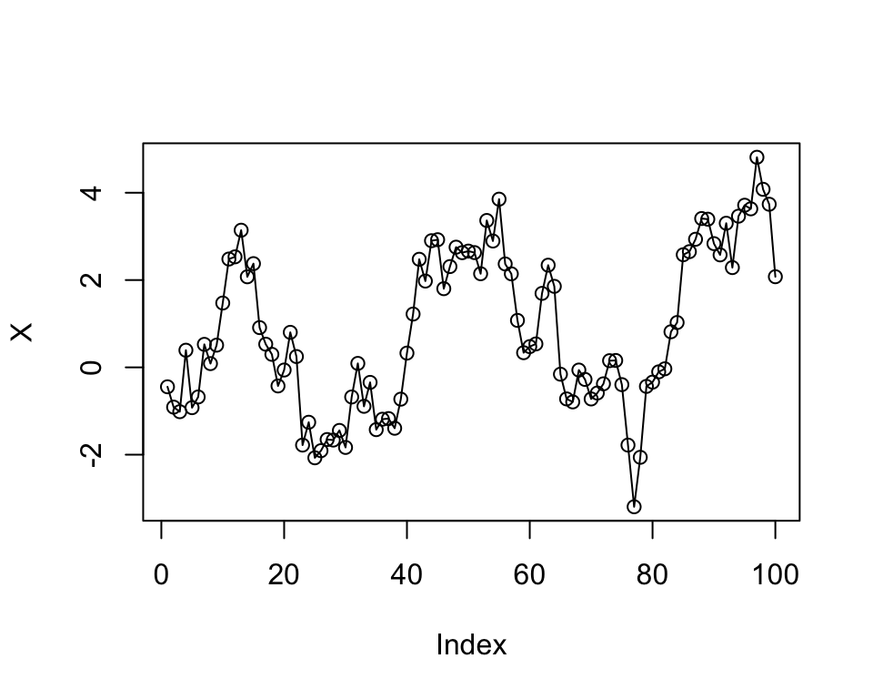

```r
  set.seed(135)                    # set seed
  ep = rnorm(100,0,1)              # RS from N(0,1)
  X  = cumsum(ep)                  # Y is mu + random noise

  plot(X, type="o")
```

What is the mean and variance of Random Walk?

### Mean

$$E(X_t) = E \Big( \sum_{i=1}^t \epsilon_i\Big) = \sum_{i=1}^t E(\epsilon_i) = \sum_{i=1}^n 0 = 0$$

### Variance

$$V(X_t) = V \Big( \sum_{i=1}^t \epsilon_i \Big) = \sum_{i=1}^t V(\epsilon_i) = \sum_{i=1}^t 1 = t$$

Variance of RW grows liniarly with time

SD of Random Walk grows as $\sqrt t$

Therefore Random Walk is non-stationary

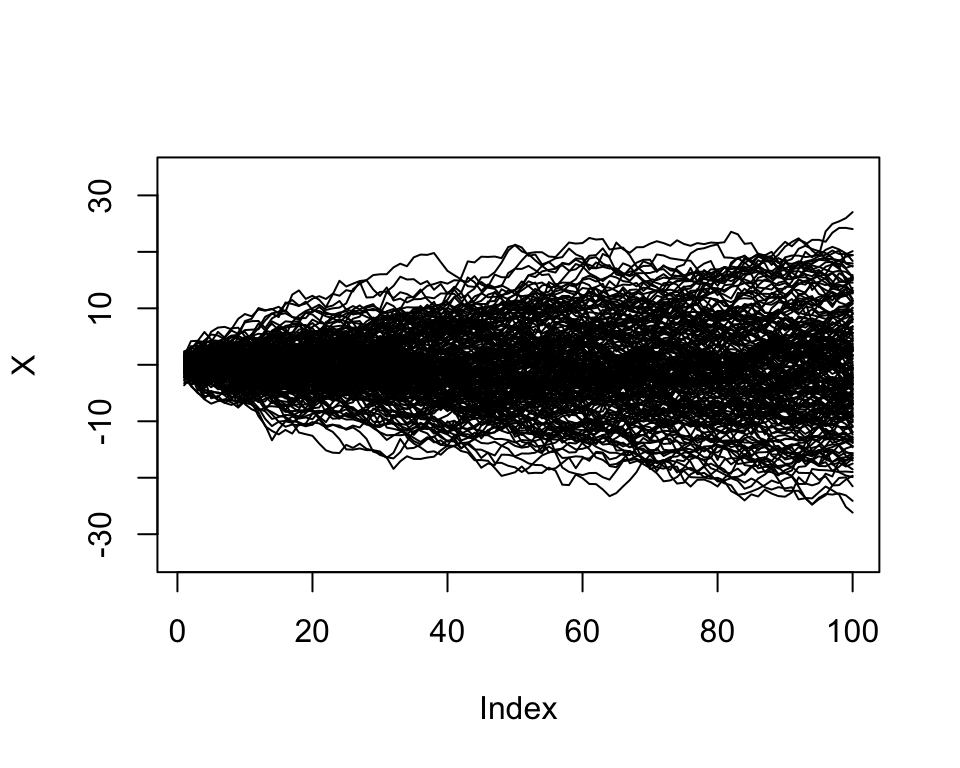

```r
  set.seed(5523)
  ep = rnorm(100,0,1)                # RS from N(0,1)
  X = cumsum(ep)                     # X is Random Walk
  plot(X, type="l", ylim=c(-34, 34))

  for (i in 1:200){
    ep = rnorm(100,0,1)
    X = cumsum(ep)
    lines(X)
  }
```

What is mean and SD of $X_{80}$?

### Example - Dow Jones

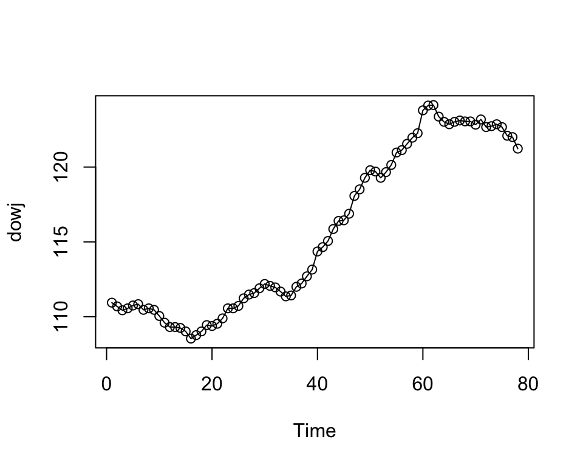

```r
#  The Dow Jones Utilities Index, Aug. 28–Dec. 18, 1972;
#  DOWJ.TSM from Brockwell and Davis (2002)

   D  <- read.csv("https://nmimoto.github.io/datasets/dowj.csv")
   D1 <- ts(D, start=c(1,1), freq=1)

   plot(D1, type='o')
```

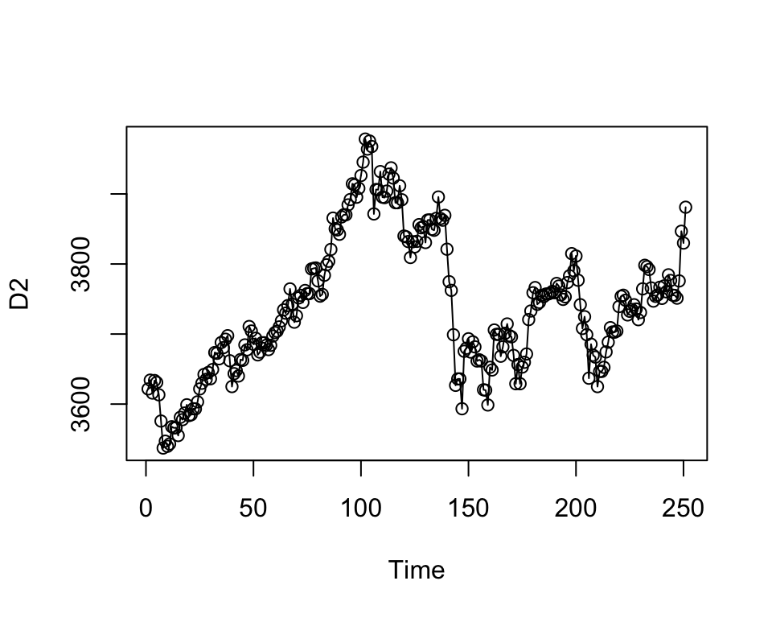

```r
#[djao2]-----------------------------------------------------------------------
#  Closing values of the DowJones Index of stocks on the New York Stock Exchange
#  251 successive trading days  Sep 10, 1993 to Aug 26, 1994
#                                    djao2.tsm From Brockwell and Davis (2002)

    D  <- read.table("https://nmimoto.github.io/datasets/djao2.csv", header=T)
    D2 <- ts(D$DJ, start=c(1,1), freq=1)

    plot(D2, type='o')
```

## Summary

- Trend can be additive or multiplicative. If multiplecative, we can take log to make it additive.
- Trend can be deterministic or random. If deterministic, we can try regression with $Y_t ~ a + bt$.
- If trend is random, we can try using Random Walk as a model for the trend.
- Random Walk is non-stationary because of increasing variance.